# Intro to R

# Set up

Go ahead and run this:

```r
install.packages("tidyverse")
```

## R and R-studio basics

### Loading Packages

- Like Python, R is open source and easily extensible.
- `install.packages()` installs a package.
- You only need to install a package once, but you need to load the package each time you restart R.
- Unlike Python, you will generally load the whole package with `library(packagename)`

```r
library(tidyverse) # this is really a collection of packages.
```

### Loading Packages

In some scenarios, I may want to access a package function without loading the entire package. I can do this using the `::` function.

For instance, this code would use the `backtick` function from the `glue` package, without loading the glue package into memory.

```r
glue::backtick("adding some backticks")
```

```
[1] "`adding some backticks`"
```

### Assignment with `<-`

In R, you’ll frequently see the `<-` used instead of `=` to assign variables.

```r
x <- 10
```

The `=` still works, but is less common.

```r
x = 10
```

### Try it out: loading data from a URL

Run these commands to import a sample from the National Health and Nutrition Examination Survey from a github repo:

```r
library(tidyverse)
nhanes<-read_csv("https://raw.githubusercontent.com/Neilblund/SDSB340-Spring-2026/refs/heads/master/Data/nhanes.csv")
```

#### Note on this data

**Caution**

For the sake of simplicity, this version of NHANES has been re-sampled to be more-or-less representative of the target population.

In practice, NHANES, like most surveys, uses a complex survey design and requires weighting to get responses that can be generalized to the U.S. public.

All this is to say: if you use this code to analyze actual NHANES data that you download from the CDC, you’ll get incorrect results. We’ll talk about how to do this properly in a later class.

#### Viewing data

Once you’ve imported the data, you should see it appear in the upper-right hand “Environment” pane of R-Studio.

Click on the name in the environment pane to bring up a view of the data.

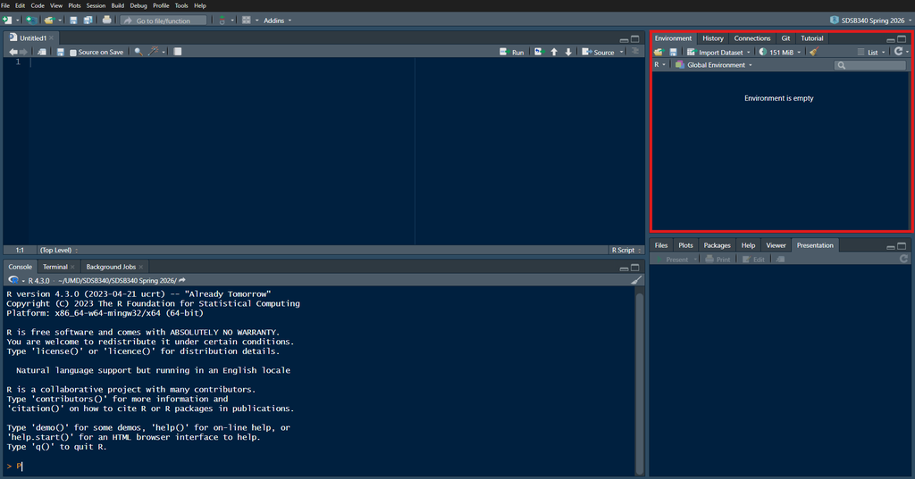

#### Saving a script

- Go to File -> New File -> R script or press CTRL + SHIFT + N to open a new R script.
- Paste the commands you just used into the window.
- Add a comment to the script by adding a “#” followed by some text.
- Save it by pressing CTRL + S, or using the file menu.

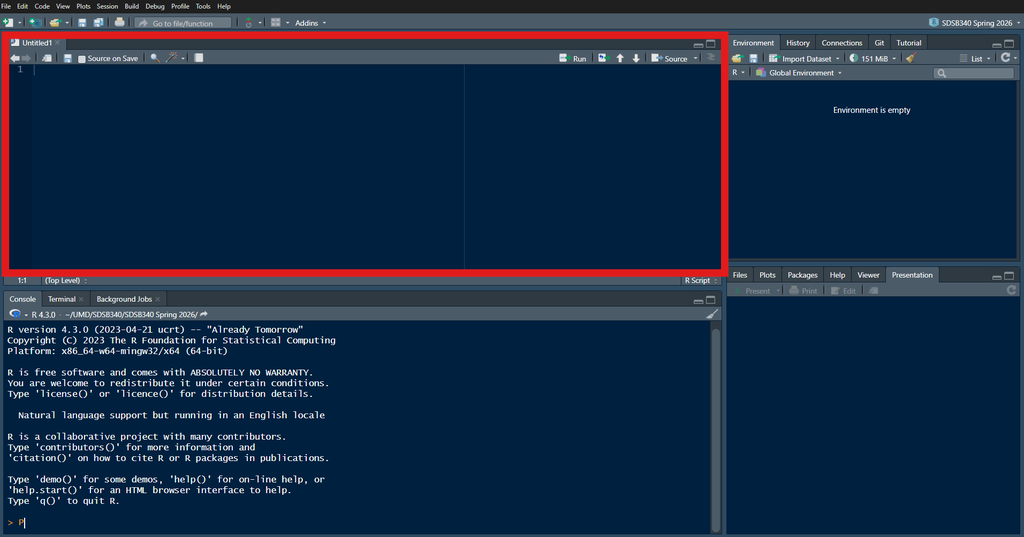

#### Executing commands

- Restart R, open your script and then press CTRL + ENTER to execute a line of code.
- Or, execute the entire script by pressing CTRL + SHIFT + ENTER
- Ideally, you should aim to write scripts that you can execute in order without errors.

## Indexing

### Positional Indexing

R uses 1 based indexing instead of 0 based indexing like Python:

```python
# indexing a vector in python
vec = ["first", "second", "third", "fourth"]

vec[0]
```

```
'first'
```

```r
# indexing a vector in R
vec <- c("first", "second", "third", "fourth")

vec[1]
```

```
[1] "first"
```

### Logical Indexing

R also allows indexing with a boolean (`TRUE`/`FALSE`) vector.

```r
# make a vector
vec <- c(1 ,2 ,3 , 4)

# TRUE for all elements > 2
vec >2
```

```
[1] FALSE FALSE  TRUE  TRUE
```

```r
# Returning all elements greater than 2

vec[vec>2]
```

```
[1] 3 4
```

### Logical operators

R’s [logical operators](https://stat.ethz.ch/R-manual/R-devel/library/base/html/Logic.html) are very similar to Python’s:

```r
vec <- c(1 ,2 ,3 , 4)

vec == 1 | vec ==2
```

```
[1]  TRUE  TRUE FALSE FALSE
```

```r
vec > 2 & vec < 4
```

```
[1] FALSE FALSE  TRUE FALSE
```

```r
vec!=3
```

```
[1]  TRUE  TRUE FALSE  TRUE
```

```r
vec %in% c(2, 4)
```

```
[1] FALSE  TRUE FALSE  TRUE
```

### Name based indexing

For R objects that have a “names” attribute, we can also use name-based indexing:

```r
vec<-c("A" = 1, "B" = 2, "C" = 3)

vec["B"]
```

```
B
2
```

### Data frame indexing

In most cases, we’ll store tabular data in a data frame (or a tibble, which is a close relative):

```r
nhanes
```

```
# A tibble: 10,000 × 76
      ID SurveyYr Gender   Age AgeDecade AgeMonths Race1 Race3 Education
   <dbl> <chr>    <chr>  <dbl> <chr>         <dbl> <chr> <chr> <chr>
 1 51624 2009_10  male      34 30-39           409 White <NA>  High School
 2 51624 2009_10  male      34 30-39           409 White <NA>  High School
 3 51624 2009_10  male      34 30-39           409 White <NA>  High School
 4 51625 2009_10  male       4 0-9              49 Other <NA>  <NA>
 5 51630 2009_10  female    49 40-49           596 White <NA>  Some College
 6 51638 2009_10  male       9 0-9             115 White <NA>  <NA>
 7 51646 2009_10  male       8 0-9             101 White <NA>  <NA>
 8 51647 2009_10  female    45 40-49           541 White <NA>  College Grad
 9 51647 2009_10  female    45 40-49           541 White <NA>  College Grad
10 51647 2009_10  female    45 40-49           541 White <NA>  College Grad
# ℹ 9,990 more rows
# ℹ 67 more variables: MaritalStatus <chr>, HHIncome <chr>, HHIncomeMid <dbl>,
#   Poverty <dbl>, HomeRooms <dbl>, HomeOwn <chr>, Work <chr>, Weight <dbl>,
#   Length <dbl>, HeadCirc <dbl>, Height <dbl>, BMI <dbl>,
#   BMICatUnder20yrs <chr>, BMI_WHO <chr>, Pulse <dbl>, BPSysAve <dbl>,
#   BPDiaAve <dbl>, BPSys1 <dbl>, BPDia1 <dbl>, BPSys2 <dbl>, BPDia2 <dbl>,
#   BPSys3 <dbl>, BPDia3 <dbl>, Testosterone <dbl>, DirectChol <dbl>, …
```

Note that we have a mixture of text and numbers here.

### Data frame indexing

We can access specific cells of this data frame by specifying a row and colum number `data[rowindex, columnindex]`

```r
# first row, third column:
nhanes[1, 3]
```

```
# A tibble: 1 × 1
  Gender
  <chr>
1 male
```

### Data frame indexing

Leaving the row index blank will return an entire column:

```r
nhanes[,1]
```

```
# A tibble: 10,000 × 1
      ID
   <dbl>
 1 51624
 2 51624
 3 51624
 4 51625
 5 51630
 6 51638
 7 51646
 8 51647
 9 51647
10 51647
# ℹ 9,990 more rows
```

Leaving the column index blank would return the entire row:

```r
nhanes[1,]
```

```
# A tibble: 1 × 76
     ID SurveyYr Gender   Age AgeDecade AgeMonths Race1 Race3 Education
  <dbl> <chr>    <chr>  <dbl> <chr>         <dbl> <chr> <chr> <chr>
1 51624 2009_10  male      34 30-39           409 White <NA>  High School
# ℹ 67 more variables: MaritalStatus <chr>, HHIncome <chr>, HHIncomeMid <dbl>,
#   Poverty <dbl>, HomeRooms <dbl>, HomeOwn <chr>, Work <chr>, Weight <dbl>,
#   Length <dbl>, HeadCirc <dbl>, Height <dbl>, BMI <dbl>,
#   BMICatUnder20yrs <chr>, BMI_WHO <chr>, Pulse <dbl>, BPSysAve <dbl>,
#   BPDiaAve <dbl>, BPSys1 <dbl>, BPDia1 <dbl>, BPSys2 <dbl>, BPDia2 <dbl>,
#   BPSys3 <dbl>, BPDia3 <dbl>, Testosterone <dbl>, DirectChol <dbl>,
#   TotChol <dbl>, UrineVol1 <dbl>, UrineFlow1 <dbl>, UrineVol2 <dbl>, …
```

### Data frame indexing

More often, we’ll access data frame columns using the column name with the `$` notation.

For instance, this would give us the entire marital status column:

```r
nhanes$MaritalStatus
```

```
    [1] "Married"      "Married"      "Married"      NA
    [5] "LivePartner"  NA             NA             "Married"
    [9] "Married"      "Married"      "Married"      "Divorced"
   [13] "Married"      NA             "Married"      "NeverMarried"
   [17] NA             "Married"      "Married"      NA
   [21] "Married"      "Married"      "Married"      "Divorced"
   [25] "Divorced"     "Married"      NA             "Separated"
   [29] "Married"      "Married"      "Widowed"      "Married"
   [33] "Widowed"      "Widowed"      "Married"      "Married"
   [37] "Married"      NA             NA             NA
   [41] NA             NA             NA             NA
   [45] "LivePartner"  "Married"      "NeverMarried" "Married"
   [49] "Married"      "NeverMarried" "NeverMarried" NA
   [53] NA             "Married"      "NeverMarried" "Widowed"
   [57] NA             "Married"      "Married"      "Married"
```

[output cut: 2485 more lines]

### Data frame indexing

We can combine numeric indexing with the `$` notation to get specific elements from a column like the first 10 marital statuses:

```r
nhanes$MaritalStatus[1:10]
```

```
 [1] "Married"     "Married"     "Married"     NA            "LivePartner"
 [6] NA            NA            "Married"     "Married"     "Married"
```

### Data frame indexing

We can also use logical indexing to do things like get all the marital statuses for people over 65:

```r
nhanes$MaritalStatus[nhanes$Age>65]
```

```
   [1] "Married"      "Widowed"      "Married"      "Married"
   [5] "Married"      "Married"      "Married"      "Married"
   [9] "Married"      "Divorced"     "Widowed"      "Married"
  [13] "Married"      "Widowed"      "Widowed"      "Married"
  [17] "Widowed"      "Married"      "Married"      "Married"
  [21] "Widowed"      "Widowed"      "Widowed"      "Widowed"
  [25] "Married"      "Married"      "Divorced"     "Married"
  [29] "Married"      "Separated"    "Married"      "Married"
  [33] "Widowed"      "Widowed"      "Married"      "Divorced"
  [37] "Widowed"      "Widowed"      "Widowed"      "Widowed"
  [41] "Married"      "Divorced"     "Widowed"      "Widowed"
  [45] "Married"      "Divorced"     "Divorced"     "Married"
  [49] "Married"      "Married"      "Widowed"      "Married"
  [53] "Married"      "Married"      "Widowed"      "Widowed"
  [57] "NeverMarried" "Married"      "Widowed"      "Married"
```

[output cut: 282 more lines]

### Data frame indexing

```r
nhanes_male_children<-nhanes[nhanes$Age<=18 & nhanes$Gender=="male",]
nhanes_male_children[1:10, ] # first ten rows
```

```
# A tibble: 10 × 76
      ID SurveyYr Gender   Age AgeDecade AgeMonths Race1 Race3 Education
   <dbl> <chr>    <chr>  <dbl> <chr>         <dbl> <chr> <chr> <chr>
 1 51625 2009_10  male       4 0-9              49 Other <NA>  <NA>
 2 51638 2009_10  male       9 0-9             115 White <NA>  <NA>
 3 51646 2009_10  male       8 0-9             101 White <NA>  <NA>
 4 51679 2009_10  male      16 10-19           194 Other <NA>  <NA>
 5 51695 2009_10  male       8 0-9             104 White <NA>  <NA>
 6 51719 2009_10  male      17 10-19           211 White <NA>  <NA>
 7 51720 2009_10  male      12 10-19           152 Other <NA>  <NA>
 8 51720 2009_10  male      12 10-19           152 Other <NA>  <NA>
 9 51722 2009_10  male      16 10-19           199 White <NA>  <NA>
10 51722 2009_10  male      16 10-19           199 White <NA>  <NA>
# ℹ 67 more variables: MaritalStatus <chr>, HHIncome <chr>, HHIncomeMid <dbl>,
#   Poverty <dbl>, HomeRooms <dbl>, HomeOwn <chr>, Work <chr>, Weight <dbl>,
#   Length <dbl>, HeadCirc <dbl>, Height <dbl>, BMI <dbl>,
#   BMICatUnder20yrs <chr>, BMI_WHO <chr>, Pulse <dbl>, BPSysAve <dbl>,
#   BPDiaAve <dbl>, BPSys1 <dbl>, BPDia1 <dbl>, BPSys2 <dbl>, BPDia2 <dbl>,
#   BPSys3 <dbl>, BPDia3 <dbl>, Testosterone <dbl>, DirectChol <dbl>,
#   TotChol <dbl>, UrineVol1 <dbl>, UrineFlow1 <dbl>, UrineVol2 <dbl>, …
```

### Try it out: indexing

- The `is.na()` function returns `TRUE` if an element has an `NA` value (missing data). Make a new data frame with only observations where the `Height` variable is not missing (you can use the `!` symbol to negate a comparison). Call the new data `nhanes_nonmissing`
- Use `$` to get a vector with only heights for adults.
- Use the `hist` function to plot a histogram of adult heights.

```r
nhanes_non_missing<-nhanes[!is.na(nhanes$Height),]

nhanes_non_missing$Height[nhanes_non_missing$Age>=18]

hist(nhanes_non_missing$Height[nhanes_non_missing$Age>=18])
```

## The Tidyverse

### The Tidyverse

In this class, we’ll often use [`tidyverse`](https://tidyverse.org/) packages for a lot of our data manipulation and code.

The tidyverse is a collection of packages with some shared design features and grammar.

### The .data argument

In this class, we’ll often use `tidyverse` commands for data manipulation. Many of these commands will allow us to use a `.data` argument and then leave out the `$` notation:

```r
select(.data=nhanes,PhysActive)
```

```
# A tibble: 10,000 × 1
   PhysActive
   <chr>
 1 No
 2 No
 3 No
 4 <NA>
 5 No
 6 <NA>
 7 <NA>
 8 Yes
 9 Yes
10 Yes
# ℹ 9,990 more rows
```

### The .data argument

This is convenient when we want to work with multiple columns without typing out the data set name over and over:

```r
select(.data = nhanes, Height, Gender, Age)
```

```
# A tibble: 10,000 × 3
   Height Gender   Age
    <dbl> <chr>  <dbl>
 1   165. male      34
 2   165. male      34
 3   165. male      34
 4   105. male       4
 5   168. female    49
 6   133. male       9
 7   131. male       8
 8   167. female    45
 9   167. female    45
10   167. female    45
# ℹ 9,990 more rows
```

### Pipes

You’ll often see R code with the “pipe” operator, which either looks like this `|>` or `%>%`.

Pipes are just a convenient way to write R code that has lots of steps.

### Pipes

Whatever is on the left hand side of the pipe is inserted as the first argument to whatever is on the right hand side:

```r
"hello"|>print()
```

```
[1] "hello"
```

```r
print("hello")
```

```
[1] "hello"
```

### Pipes

Take this command:

```r
select(.data=nhanes, Height)
```

We can re-write it using a pipe:

```r
nhanes|>
  select(Height)
```

```
# A tibble: 10,000 × 1
   Height
    <dbl>
 1   165.
 2   165.
 3   165.
 4   105.
 5   168.
 6   133.
 7   131.
 8   167.
 9   167.
10   167.
# ℹ 9,990 more rows
```

### Pipes

Pipes are especially useful when we have to perform several modifications on a piece of data:

```r
nhanes|>
  filter(Age>=18)|>  # filter performs logical sub-setting
  pluck("Height")|> # pluck takes a single column and returns a vector
  hist()            # hist makes a histogram
```

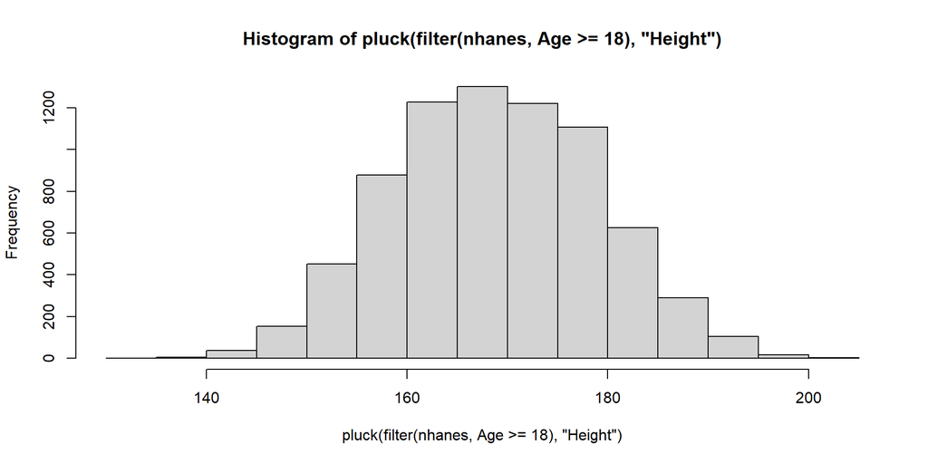

## Data manipulation with dplyr

### Filter and select

You’ve already seen these, but they’re actually `dplyr` functions. `filter` performs logical subsetting. While `select` allows you to select specific columns from a data frame:

```r
# People who sleep less than five hours a night but say they haven't
# reported sleep issues to a doctor
nhanes|>
  filter(SleepHrsNight < 5)|>
  filter(SleepTrouble == "No")|>
  select(Age, Gender,SleepTrouble)
```

```
# A tibble: 173 × 3
     Age Gender SleepTrouble
   <dbl> <chr>  <chr>
 1    46 male   No
 2    46 male   No
 3    55 male   No
 4    50 female No
 5    72 male   No
 6    45 male   No
 7    45 male   No
 8    41 male   No
 9    42 female No
10    22 male   No
# ℹ 163 more rows
```

### Filter and select

```r
# Biggest babies:

nhanes|>
  filter(AgeMonths <= 6)|>
  select(AgeMonths, Gender, HeadCirc, Weight)|>
  arrange(-Weight) # sort the data by a variable (descending order)
```

```
# A tibble: 88 × 4
   AgeMonths Gender HeadCirc Weight
       <dbl> <chr>     <dbl>  <dbl>
 1         5 female     45.4    9.8
 2         6 male       44.3    9.4
 3         4 male       43.2    9.3
 4         6 male       45      9.3
 5         6 female     44.3    9
 6         6 female     44.3    9
 7         5 male       43      8.7
 8         4 female     43.2    8.7
 9         6 female     44      8.6
10         4 female     42.4    8.6
# ℹ 78 more rows
```

### Mutate

Mutate will allow us to add an additional column to an existing data set.

```r
nhanes<-nhanes|>
  # n() is shortcut for counting rows in dplyr functions:
  mutate(total_responses = n())

nhanes$total_responses[1:10]
```

```
 [1] 10000 10000 10000 10000 10000 10000 10000 10000 10000 10000
```

Note that we could also do this like:

```r
nhanes$total_responses<-nrow(nhanes) # nrow counts rows in a data frame

nhanes$total_responses[1:10]
```

… but `mutate` will do some other things that this approach doesn’t.

### Mutate to make a factor variable

Factor variables are a method for handling categorical data in R. Since we’re working with surveys, this will come up quite a bit.

By default, many R functions will alphabetize categorical data, but sometimes that doesn’t make sense:

```r
table(nhanes$HealthGen)
```

```
Excellent      Fair      Good      Poor     Vgood
      878      1010      2956       187      2508
```

### Mutate to make a factor variable

R factors associate labels with numeric values, so they let us override the default ordering of categories:

```r
# fct_relevel re-orders factors

fct_relevel(nhanes$HealthGen, "Poor", "Fair", "Good", "Vgood", "Excellent")|>
  table()
```

```
     Poor      Fair      Good     Vgood Excellent
      187      1010      2956      2508       878
```

### Try it out: Mutating to create a factor variable

- `Depressed` asks respondents how often they’ve felt symptoms of depression in the last few weeks. Responses are: None, Most, and Several.
- Use `mutate` with `fct_relevel` to make a new variable called `Depressed_factor` that correctly arranges the `Depressed` values.

```r
nhanes<-nhanes|>
  mutate(Depressed_factor = fct_relevel(Depressed, "None", "Several", "Most"))

table(nhanes$Depressed_factor)
```

```
   None Several    Most
   5246    1009     418
```

### Grouping

Most of our survey analyses will require us to do some kind of aggregation, like calculate the percentage of people who said they “agree” with a statement at different age levels.

The `group_by` function in dplyr gives us an easy way to perform these kinds of aggregations.

### Grouping

On its own, `group_by` doesn’t appear to change anything in our data:

```r
nhanes|>
  group_by(Gender)
```

```
# A tibble: 10,000 × 78
      ID SurveyYr Gender   Age AgeDecade AgeMonths Race1 Race3 Education
   <dbl> <chr>    <chr>  <dbl> <chr>         <dbl> <chr> <chr> <chr>
 1 51624 2009_10  male      34 30-39           409 White <NA>  High School
 2 51624 2009_10  male      34 30-39           409 White <NA>  High School
 3 51624 2009_10  male      34 30-39           409 White <NA>  High School
 4 51625 2009_10  male       4 0-9              49 Other <NA>  <NA>
 5 51630 2009_10  female    49 40-49           596 White <NA>  Some College
 6 51638 2009_10  male       9 0-9             115 White <NA>  <NA>
 7 51646 2009_10  male       8 0-9             101 White <NA>  <NA>
 8 51647 2009_10  female    45 40-49           541 White <NA>  College Grad
 9 51647 2009_10  female    45 40-49           541 White <NA>  College Grad
10 51647 2009_10  female    45 40-49           541 White <NA>  College Grad
# ℹ 9,990 more rows
# ℹ 69 more variables: MaritalStatus <chr>, HHIncome <chr>, HHIncomeMid <dbl>,
#   Poverty <dbl>, HomeRooms <dbl>, HomeOwn <chr>, Work <chr>, Weight <dbl>,
#   Length <dbl>, HeadCirc <dbl>, Height <dbl>, BMI <dbl>,
#   BMICatUnder20yrs <chr>, BMI_WHO <chr>, Pulse <dbl>, BPSysAve <dbl>,
#   BPDiaAve <dbl>, BPSys1 <dbl>, BPDia1 <dbl>, BPSys2 <dbl>, BPDia2 <dbl>,
#   BPSys3 <dbl>, BPDia3 <dbl>, Testosterone <dbl>, DirectChol <dbl>, …
```

### Grouping and summarizing

Where `group_by` becomes useful is when we pair it with commands like `summarize` to calculate one or more summary statistics across levels of a group:

```r
nhanes|>
  group_by(Gender)|>
  # na.rm=TRUE will drop NA values before calculating (otherwise this returns NA)
  summarize(mean_pulse = mean(Pulse, na.rm=T)
            )
```

```
# A tibble: 2 × 2
  Gender mean_pulse
  <chr>       <dbl>
1 female       75.4
2 male         71.7
```

### Grouping and summarizing

We could use `group_by` to create a version of the frequency table of depression symptoms we made in the last section:

```r
nhanes|>
  group_by(Depressed_factor)|>
  summarise(n = n())
```

```
# A tibble: 4 × 2
  Depressed_factor     n
  <fct>            <int>
1 None              5246
2 Several           1009
3 Most               418
4 <NA>              3327
```

### Grouping and summarizing

But what we probably want here is a proportion, we can get this by adding a mutate step:

```r
nhanes|>
  group_by(Depressed)|>
  summarise(n = n())|>
  mutate(proportion = n /sum(n))
```

```
# A tibble: 4 × 3
  Depressed     n proportion
  <chr>     <int>      <dbl>
1 Most        418     0.0418
2 None       5246     0.525
3 Several    1009     0.101
4 <NA>       3327     0.333
```

### Grouping and mutating

Many other `dplyr` functions will respect the grouping context. For instance, `group_by` followed by `mutate` will let us add an aggregate statistic to the original data set:

```r
# Gender, Height, and average height by Gender for each respondent:
nhanes|>
  group_by(Gender)|>
  mutate(mean_height = mean(Height, na.rm=T))|>
  select(Gender, Height, mean_height)
```

```
# A tibble: 10,000 × 3
   Gender Height mean_height
   <chr>   <dbl>       <dbl>
 1 male     165.        167.
 2 male     165.        167.
 3 male     165.        167.
 4 male     105.        167.
 5 female   168.        157.
 6 male     133.        167.
 7 male     131.        167.
 8 female   167.        157.
 9 female   167.        157.
10 female   167.        157.
# ℹ 9,990 more rows
```

### Grouping and slicing

Here’s an example of getting the babies with the biggest head circumference by using `filter` with `group_by`

```r
nhanes|>
  filter(AgeMonths <= 6)|>
  arrange(AgeMonths)|>
  group_by(AgeMonths)|>
  filter(HeadCirc == max(HeadCirc))|>
  select(Gender, AgeMonths, HeadCirc, Weight)
```

```
# A tibble: 7 × 4
  Gender AgeMonths HeadCirc Weight
  <chr>      <dbl>    <dbl>  <dbl>
1 male           0     39.5    5.3
2 male           1     41.4    5.3
3 male           2     43.8    7.5
4 female         3     44.6    7.8
5 female         4     43.8    7.8
6 female         5     45.4    9.8
7 male           6     45      9.3
```

### Grouping and ungrouping

Be careful: `group_by` will persist even after you use functions like `filter` or `mutate`, so be sure to `ungroup` the data frame when you no longer need to aggregate over a group!

```r
nhanes|>
  filter(AgeMonths <= 6)|>
  arrange(AgeMonths)|>
  group_by(AgeMonths)|>
  summarize(mean_HeadCirc = mean(HeadCirc, na.rm=T))
```

```
# A tibble: 7 × 2
  AgeMonths mean_HeadCirc
      <dbl>         <dbl>
1         0          37.8
2         1          39.6
3         2          40.7
4         3          41.9
5         4          42.0
6         5          43.0
7         6          43.8
```

```r
nhanes|>
  filter(AgeMonths <= 6)|>
  arrange(AgeMonths)|>
  group_by(AgeMonths)|>
  ungroup() |> # UNgrouping
  summarize(mean_HeadCirc = mean(HeadCirc, na.rm=T))
```

```
# A tibble: 1 × 1
  mean_HeadCirc
          <dbl>
1          41.2
```

### Try it out: grouping and summarizing

- Calculate the median `PhysActiveDays` (Physically active days per week) for men compared to women.
- Calculate the proportion of respondents who said they had smoked at least 100 cigarettes in their lifetime (`Smoke100`)
- Re-calculate the answer from the previous step, but use `filter` first to remove people who have an `NA` value before you calculate the proportions.

```r
nhanes|>
  group_by(Gender)|>
  summarise(mean_active = median(PhysActiveDays, na.rm=T))

nhanes|>
  group_by(Smoke100)|>
  summarise(n = n())|>
  mutate(proportion = n/sum(n))

nhanes|>
  filter(!is.na(Smoke100))|>
  group_by(Smoke100)|>
  summarise(n = n())|>
  mutate(proportion = n/sum(n))
```

## Making a formatted table

It’s rarely a good idea to show un-formatted R output in a finished product like a report or presentation (unless your goal is teaching people R)

Fortunately there are a whole bunch of add-on packages that can format output for us.

We’ll primarily use `gt` and `gtsummary`, mostly because they work well with other packages in this class.

```r
library(gt)
library(gtsummary)
```

### Making a formatted table with gt

`gt()` is all we need to get formatted output:

```r
nhanes|>
  group_by(Depressed_factor)|>
  summarise(n = n())|>
  mutate(proportion = n /sum(n))|>
  gt()
```

| Depressed_factor | n | proportion |
| --- | --- | --- |
| None | 5246 | 0.5246 |
| Several | 1009 | 0.1009 |
| Most | 418 | 0.0418 |
| NA | 3327 | 0.3327 |

### Making a formatted table with gt

But we’ll usually want to do some additional formatting.

```r
nhanes|>
  group_by(Depressed_factor)|>
  summarise(n = n())|>
  mutate(proportion = n /sum(n))|>
  gt()|>
  fmt_integer(n)|>
  fmt_percent(proportion)
```

| Depressed_factor | n | proportion |
| --- | --- | --- |
| None | 5,246 | 52.46% |
| Several | 1,009 | 10.09% |
| Most | 418 | 4.18% |
| NA | 3,327 | 33.27% |

### Making a formatted table with gt

But we’ll usually want to do some additional formatting.

```r
nhanes|>
  group_by(Depressed_factor)|>
  summarise(n = n())|>
  mutate(proportion = n /sum(n))|>
  gt()|>
  fmt_integer(n)|>
  fmt_percent(proportion, decimals=1)|>
  cols_label(
    proportion = "Percent",
    n = "N",
    Depressed_factor =  "Days felt depressed"
             )
```

| Days felt depressed | N | Percent |
| --- | --- | --- |
| None | 5,246 | 52.5% |
| Several | 1,009 | 10.1% |
| Most | 418 | 4.2% |
| NA | 3,327 | 33.3% |

### Making a formatted table with gt

But we’ll usually want to do some additional formatting.

```r
nhanes|>
  group_by(Depressed_factor)|>
  summarise(n = n())|>
  mutate(proportion = n /sum(n))|>
  gt()|>
  fmt_integer(n)|>
  fmt_percent(proportion, decimals=1)|>
  cols_label(
    proportion = "Percent",
    n = "N",
    Depressed_factor = "Days felt depressed"
             )|>
  sub_missing(missing_text = "Missing")
```

| Days felt depressed | N | Percent |
| --- | --- | --- |
| None | 5,246 | 52.5% |
| Several | 1,009 | 10.1% |
| Most | 418 | 4.2% |
| Missing | 3,327 | 33.3% |

### Making a formatted table with gtsummary

The `gtsummary` library is a wrapper around `gt` that will do some aggregating and automatic formatting for us. It’s somewhat inflexible, which I why you still need to learn some dplyr, but it works great here with a lot less code:

```r
nhanes|>
  select(Depressed_factor)|>
  tbl_summary()
```

| **Characteristic** | **N = 10,000**<sup>1</sup> |
| --- | --- |
| Depressed_factor |  |
| None | 5,246 (79%) |
| Several | 1,009 (15%) |
| Most | 418 (6.3%) |
| Unknown | 3,327 |

<sup>1</sup> n (%)

### Making a formatted table with gtsummary

The `gtsummary` library is a wrapper around `gt` that will do some aggregating and automatic formatting for us. It’s somewhat inflexible, which I why you still need to learn some dplyr, but it works great here with a lot less code:

```r
nhanes|>
  select(Depressed_factor)|>
  tbl_summary(
    label  = list(
      Depressed_factor ~ "Days felt depressed"
      )
    )
```

| **Characteristic** | **N = 10,000**<sup>1</sup> |
| --- | --- |
| Days felt depressed |  |
| None | 5,246 (79%) |
| Several | 1,009 (15%) |
| Most | 418 (6.3%) |
| Unknown | 3,327 |

<sup>1</sup> n (%)